# Restaurant Reviews and Brand Clustering

Landon James

19 March 2024

## Data and Libraries

```r
library(tidyverse)
library(readxl)
library(lubridate)
library(ggplot2)
library(tidyr)
library(dplyr)
library(stats)
library(readr)
library(stringr)
library(tidytext)
library(wordcloud)
```

### Restaurant Dataset

```r
reviews <- read_csv("reviews.csv")
dim(reviews)
```

```
[1] 184   6
```

### Brands Dataset

```r
brands <- read_csv("brands.csv")
dim(brands)
```

```
[1] 686  17
```

## Restuarants and Reviews

**We will start with the `date` variable. Converting the variable to a universal date format using a lubridate function and save this variable as `datetime` in your `review` tibble.**

```r
reviews <- reviews %>% mutate(datetime = mdy(date))
reviews <- reviews %>% mutate(year_month = format(datetime, "%Y-%m"))
top_ten <- reviews %>% count(year_month) %>% arrange(desc(n)) %>% head(10)

print(top_ten)
```

```
# A tibble: 10 × 2
   year_month     n
   <chr>      <int>
 1 2019-05       12
 2 2019-07       10
 3 2019-06        9
 4 2019-08        9
 5 2020-02        9
 6 2019-11        8
 7 2019-12        8
 8 2019-04        7
 9 2020-07        7
10 2020-01        6
```

#### INFERENCE: Using the year-month and date-time variables, we can count the reviews, and determine which year-month combination has the most reviews. From the table above showing the top 10, we can see May 2019, has the most reviews at 12.

**Making timeseries plots of all restaurant reviews using `geom_freqpoly` and 30 bins. In these plots, there are custom labels for the axes, custom color for the plots, and titles.**

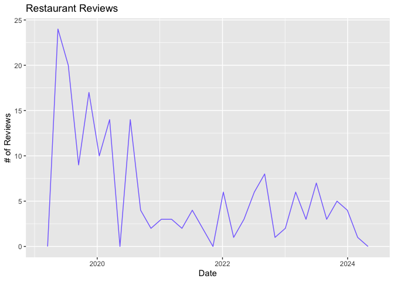

```r
ggplot(reviews, aes(x = datetime)) +
  geom_freqpoly(bins = 30, color = "slateblue1") + labs(title = "Restaurant Reviews", x = "Date", y = "# of Reviews")
```

#### INFERENCE: From this first plot we can see that the number of reviews was at its peak in 2019 before declining drastically in 2020 and never reaching a level higher than 10 reviews after 2021. We can also infer that the large spikes throughout graph are likely due to the small sample size of the dataset so we should rather compare the rough trends.

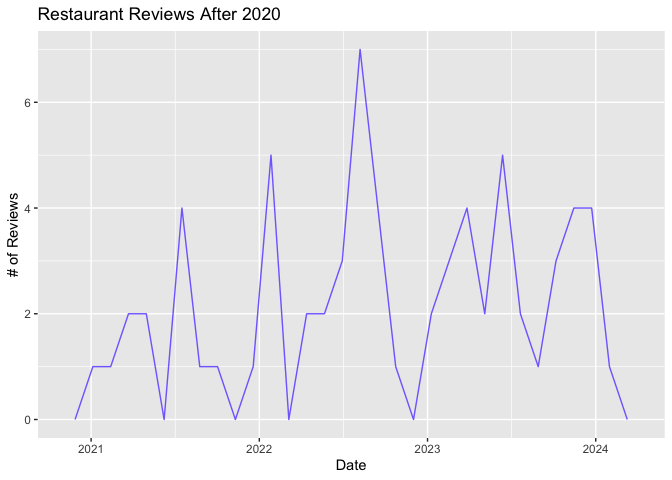

```r
ggplot(filter(reviews, year(datetime) > 2020), aes(x = datetime)) +
  geom_freqpoly(bins = 30, color = "slateblue1") + labs(title = "Restaurant Reviews After 2020", x = "Date", y = "# of Reviews")
```

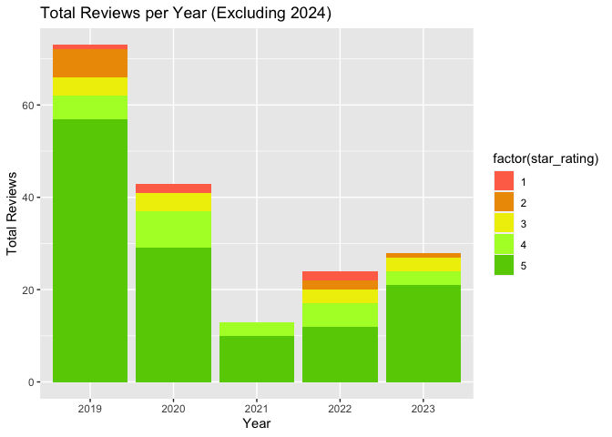

```r
ggplot(filter(reviews, year(datetime) != 2024), aes(x = factor(year(datetime)), fill = factor(star_rating))) +
  geom_bar() +
  labs(title = "Total Reviews per Year (Excluding 2024)", x = "Year", y = "Total Reviews") + scale_fill_manual(values = c("1" = "coral1", "2" = "orange2", "3" = "yellow2", "4" = "greenyellow", "5" = "chartreuse3"))
```

#### INFERENCE: From this plot above, we can see that 2019 had both the largest number of total reviews, but also the largest number of 5 star reviews. Secondly, we can see that 2021 has the lowest number of total reviews as well as 5 star reviews. I imagine this is likely because eating out became much less common during the pandemic leading to a decline in reviews.

**Now working with the `star_rating` and `pictures` variables. Finding what percentage of reviews in the dataset are NOT five stars? Finding what percentage of reviews have pictures? Then constructing a bar plot that shows the distributions of ratings (i.e., one bar for each possible star rating), with a separate plot for reviews that have pictures and those that do not include pictures.**

```r
not_5_stars <- sum(reviews$star_rating != 5)
total_r <- nrow(reviews)
perc_not_5_stars <- (not_5_stars / total_r) * 100

with_pics <- sum(reviews$pictures == "yes")
perc_with_pics <- (with_pics / total_r) * 100
```

```
Percentage of reviews NOT five stars: 28.80435 %
```

```
Percentage of reviews with pictures: 16.30435 %
```

[figure not shown]

```r
ggplot(reviews, aes(x = factor(star_rating))) +
  geom_bar(aes(fill = pictures), position = "dodge") +
  labs(title = "Ratings by Pictures", x = "Star Rating", y = "Count") + scale_fill_manual(values = c("yes" = "coral1", "no" = "darkolivegreen3"), labels = c("With Pictures", "Without Pictures")) + theme_minimal()
```

```r
chi_squared <- chisq.test(table(reviews$star_rating, reviews$pictures))
print(chi_squared)
```

```
    Pearson's Chi-squared test

data:  table(reviews$star_rating, reviews$pictures)
X-squared = 4.092, df = 4, p-value = 0.3937
```

#### This Chi-sqaured test, with a p-value of .3937 which is much larger than 0.05, tells us that there is not statistical significance in the association between the ratings and whether or not they include photos. Meaning photos dont sway the rating of a review in an y direction.

**Creating a new variable `is_helpful` that equals 1 if a review got any “helpful” votes and is 0 otherwise. And performing a chi-squared test**

```r
reviews$is_helpful <- ifelse(reviews$helpful > 0, 1, 0)
num_helpful <- sum(reviews$is_helpful == 1)

cs_result <- chisq.test(table(reviews$pictures, reviews$is_helpful))

avg_helpful <- mean(reviews$star_rating[reviews$is_helpful == 1], na.rm = TRUE)
avg_not_helpful <- mean(reviews$star_rating[reviews$is_helpful == 0], na.rm = TRUE)
```

```
# of reviews with >= 1 'helpful' vote: 76
```

```
Chi-squared p-value: 0.01328956
```

```
Avg rating for 'helpful' reviews: 4.355263
```

```
Avg rating for 'not helpful' reviews: 4.527778
```

#### INFERENCE: From our outputs and calculations above, we can see that the number of reviews with at least 1 helpful vote is 76. Following that, using our chi-squared test between pictures, and is_helpful, we can see that we calculated a p-value of 0.0132 which is less than the standard level of 0.05 meaning that the results are statistically significant and we can indeed infere that pictures have an impact on whether or not a review will recieve a helpful vote. In addition to these findings, our calculations also found that the average rating between helpful and not helpful reviews were relatively similar at 4.35, and 4.52 respectively. This helps me to understand that helpful reviews are not particularly weighted in either direction for rating.

**Now utilizing the review text in the `yelp_review_text` variable and the `tidytext` library to tokenize the dataset at the word level (i.e., so the resulting data structure has one word per row) and calling this dataframe `reviews_tokens`. Then removing all of the “stop words” using the “smart” dictionary and save the remaining words in a new dataframe, `reviews_words`. Then, using the `count()` function to construct a dataframe of word counts by star rating, and sentiment.**

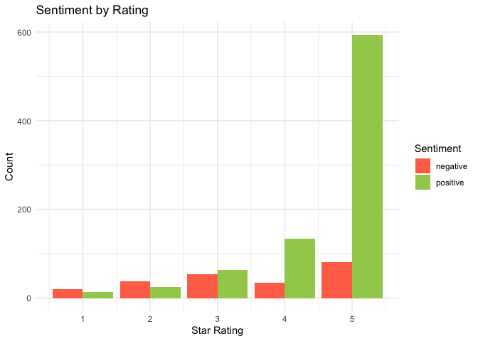

```r
reviews_tokens <- reviews %>% unnest_tokens(word, yelp_review_text)

reviews_words <- reviews_tokens %>% anti_join(stop_words)

reviews_rating_count <- reviews_words %>% inner_join(get_sentiments("bing")) %>% count(star_rating, sentiment)

ggplot(reviews_rating_count, aes(x = star_rating, y = n, fill = sentiment)) +
  geom_bar(stat = "identity", position = "dodge") +
  labs(title = "Sentiment by Rating", x = "Star Rating", y = "Count", fill = "Sentiment") + scale_fill_manual(values = c("positive" = "darkolivegreen3", "negative" = "coral1")) + theme_minimal()
```

#### INFERENCE: From this plot above we can see that the sentiment distribution between postive and negative words, as expected, heavily favors positive words as the rating increases. This make sense as you would expect 5 start reviews to be discussing the positive aspects of a restaurant rather than the negative ones.

**First, creating a `net_sentiment` variable that is equal to positive minus negative sentiment for each review then adding it to the `reviews` tibble. Second, using `count()` to identify how many words are in each review. Naming this variable `total_review_words` and adding it to the `reviews` tibble.**

```r
net_sentiment <- reviews_words %>%
  inner_join(get_sentiments("bing")) %>% count(review_num, sentiment) %>%
  spread(sentiment, n, fill = 0) %>% mutate(net_sentiment = positive - negative)

reviews <- left_join(reviews, net_sentiment, by = "review_num")

total_review_words <- reviews_words %>% count(review_num) %>% rename(total_review_words = n)

reviews <- left_join(reviews, total_review_words, by = "review_num")

avg_net_sentiment <- mean(reviews$net_sentiment, na.rm = TRUE)
avg_total_words <- mean(reviews$total_review_words, na.rm = TRUE)
```

```
Avg net sentiment: 3.324176
```

```
Avg total words: 31.96739
```

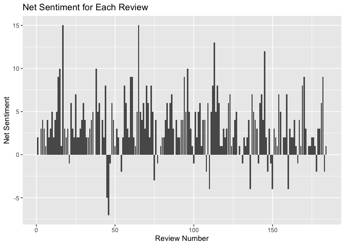

```r
ggplot(reviews, aes(x = review_num, y = net_sentiment)) +
  geom_col() + labs(title = "Net Sentiment for Each Review", x = "Review Number", y = "Net Sentiment")
```

**Will now look for specific words in the restaurant reviews. Creating four variables, one for each of the following words: “authentic”, “family”, “small”, and “tortillas”.**

```r
reviews$authentic <- as.integer(str_detect(reviews$yelp_review_text, "authentic"))
reviews$family <- as.integer(str_detect(reviews$yelp_review_text, "family"))
reviews$small <- as.integer(str_detect(reviews$yelp_review_text, "small"))
reviews$tortillas <- as.integer(str_detect(reviews$yelp_review_text, "tortillas"))

authentic_perc <- mean(reviews$authentic) * 100

tort_perc <- mean(reviews$tortillas) * 100
tort_count <- sum(reviews$tortillas)
```

```
Percentage of reviews that include 'authentic': 23.36957
```

```
Percentage of reviews that include 'tortillas': 22.28261
```

```
# of reviews that include 'tortillas': 41
```

#### Regression

**First, running a logistic regression with `is_helpful` as the dependent variable. Including three independent variables, `total_review_words`, `net_sentiment`, and `pictures`. Presenting the regression summary. Second, constructing a linear regression with `star_rating` as the dependent variable. The independent variables will include: the same three as in the first regression, plus `authentic`, `family`, `small`, and `tortillas`.**

```r
log_model <- glm(is_helpful ~ total_review_words + net_sentiment + pictures, data = reviews, family = "binomial")
summary(log_model)
```

```
Call:
glm(formula = is_helpful ~ total_review_words + net_sentiment +
    pictures, family = "binomial", data = reviews)

Coefficients:
                    Estimate Std. Error z value Pr(>|z|)
(Intercept)        -1.489238   0.306309  -4.862 1.16e-06 ***
total_review_words  0.025116   0.006966   3.606 0.000312 ***
net_sentiment       0.057864   0.051375   1.126 0.260037
picturesyes         0.977009   0.447383   2.184 0.028975 *
---
Signif. codes:  0 '***' 0.001 '**' 0.01 '*' 0.05 '.' 0.1 ' ' 1

(Dispersion parameter for binomial family taken to be 1)

    Null deviance: 247.34  on 181  degrees of freedom
Residual deviance: 219.58  on 178  degrees of freedom
  (2 observations deleted due to missingness)
AIC: 227.58

Number of Fisher Scoring iterations: 4
```

```r
lin_model <- lm(star_rating ~ total_review_words + net_sentiment + pictures + authentic + family + small + tortillas, data = reviews)
summary(lin_model)
```

```
Call:
lm(formula = star_rating ~ total_review_words + net_sentiment +
    pictures + authentic + family + small + tortillas, data = reviews)

Residuals:
    Min      1Q  Median      3Q     Max
-3.4406 -0.3690  0.1755  0.4651  2.4357

Coefficients:
                    Estimate Std. Error t value Pr(>|t|)
(Intercept)         4.397825   0.106823  41.169  < 2e-16 ***
total_review_words -0.017136   0.002686  -6.379 1.56e-09 ***
net_sentiment       0.145649   0.019814   7.351 7.37e-12 ***
picturesyes         0.090100   0.170843   0.527    0.599
authentic          -0.007735   0.151608  -0.051    0.959
family              0.171574   0.156462   1.097    0.274
small              -0.180136   0.219771  -0.820    0.414
tortillas           0.372888   0.158768   2.349    0.020 *
---
Signif. codes:  0 '***' 0.001 '**' 0.01 '*' 0.05 '.' 0.1 ' ' 1

Residual standard error: 0.8244 on 174 degrees of freedom
  (2 observations deleted due to missingness)
Multiple R-squared:  0.3678,    Adjusted R-squared:  0.3424
F-statistic: 14.46 on 7 and 174 DF,  p-value: 9.097e-15
```

#### INFERENCE: From this summary aboove, we can see that total_review_words, “authentic”, and “small” are the only variables that have a negative coefficient meaning that as the total number of words increases, and the words “authentic” or “small” are included, the rating should decrease. However, of those three only total_review_words has a p-value less than 0.05 meaning that it is the only variable of the three to be considered statistically significant. Following that, we can see that net_sentiment, pictureyes, “family”, and “tortillas” all have positive coefficients (with “tortillas” being the highest at .37), meaning that for each of these variables whether the sentiment increase, a picture is include or one of those target words is included, the rating score should increase. However, yet again, of those 4 variable, only net_sentiment and “tortillas” have statistically significant p-values.

**Creating a world cloud with words uses more than 25 times in reviews. As well as a word cloud that only includes words between 25 and 100 occurrences.**

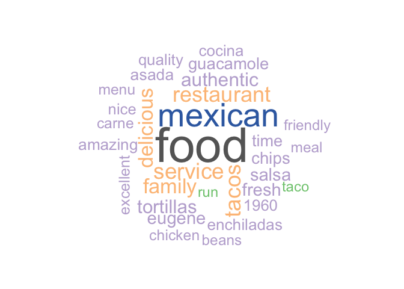

```r
word_counts <- reviews_words %>%
  count(word)

frequent_words <- word_counts %>%
  filter(n > 25)

wordcloud(words = frequent_words$word, freq = frequent_words$n, scale=c(5,1), min.freq = 25, max.words=Inf, random.order=FALSE, colors=brewer.pal(8, "Accent"), main="Frequent Words")
```

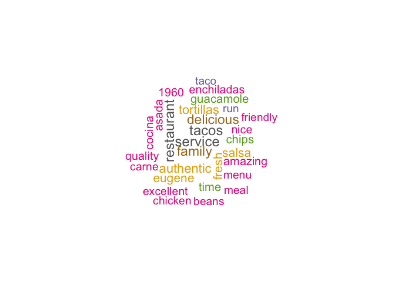

```r
moderate_words <- word_counts %>%
  filter(n > 25 & n <= 100)

wordcloud(words = moderate_words$word, freq = moderate_words$n, scale=c(1.5,1), min.freq = 26, max.freq = 100, max.words=Inf, random.order=FALSE, colors=brewer.pal(8, "Dark2"), main="Moderate Words")
```

#### INFERENCE: When comparing these two wordclouds we can see that, understanbly so, the first wordcloud has more words. We can see that the second wordcloud only has 29 different words. Personally, I think that this wordcloud is a little bit better than the first as it excludes expected and oversaturated words such as “food” and “mexican” that are likely to be involved in tons of reviews.

## Brands Clustering

**Now incorporating the `brands` dataset. Performing a K-means clustering exercise. Using all twelve brand ratings provided (complex, cool, daring, exciting, intelligent, leader, reliable, technical, trendy, unique, visible, young) in the K-means clustering. Using the “elbow method” to argue for a particular number of clusters as the right number of clusters**

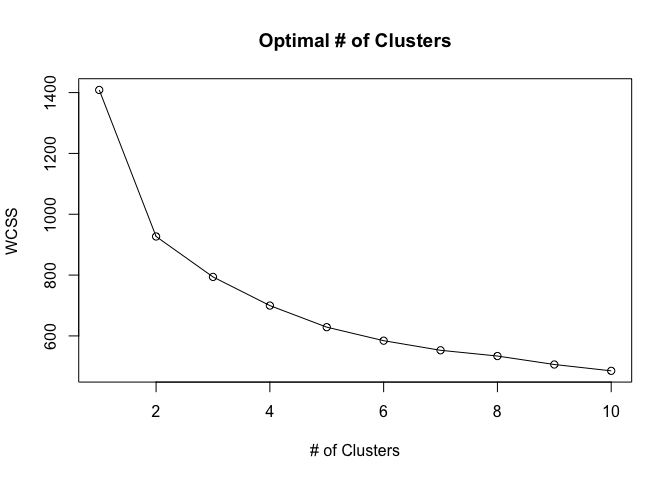

```r
brand_ratings <- brands[, c("complex", "cool", "daring", "exciting", "intelligent",
                             "leader", "reliable", "technical", "trendy",
                             "unique", "visible", "young")]

wcss <- sapply(1:10, function(k) {
  kmeans_model <- kmeans(brand_ratings, centers = k)
  kmeans_model$tot.withinss
})

plot(1:10, wcss, type = "o", xlab = "# of Clusters", ylab = "WCSS", main = "Optimal # of Clusters")
```

#### INFERENCE: From this plot above, I would say that the optimal number of clusters would be 2 because this is the point on the plot where the output no longer decreases significantly and begins to level off.

**Performing the K-means clustering using the value of K you determined in the previous question. Using `set.seed(482)` and `nstart = 10`. Set up a tabulation (using `table()`) using the `level` variable and the cluster assignments**

```r
set.seed(482)

kmeans_model <- kmeans(brand_ratings, centers = 2, nstart = 10)

brands$cluster <- kmeans_model$cluster

cluster_counts <- table(kmeans_model$cluster)
```

```
The number of brands in cluster 1 is: 311
```

```
The number of brands in cluster 2 is: 375
```

```r
tabulation <- table(Level = brands$level, Cluster = kmeans_model$cluster)
print(tabulation)
```

```
         Cluster
Level       1   2
  Middle  139 206
  Premium 108  62
  Value    64 107
```

#### INFERENCE: From this distribution of “Value”, “Middle”, and “Premium”, we can see that these 2 clusters do indeed differe. Firstly, we can see that the second cluster has a much higher rate of the lower end or “Value” and “Middle” counts while cluster 1 is definietly greater on the “Premium” side.

**Using the cluster labels to build some plots to understand the clusters. First, built a scatter plot with `cool` on the x-axis and `technical` on the y-axis. Second, making the same plot, but having `reliable` on the x-axis and `exciting` on the y-axis.**

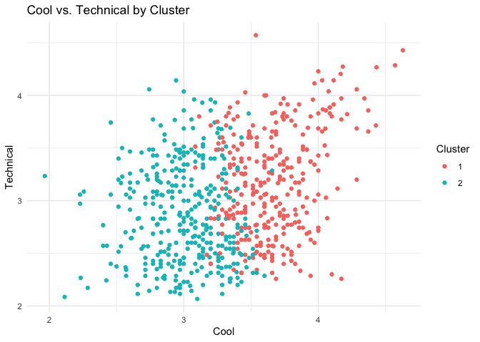

```r
ggplot(brands, aes(x = cool, y = technical, color = factor(cluster))) +
  geom_point() +
  labs(title = "Cool vs. Technical by Cluster", x = "Cool", y = "Technical", color = "Cluster") + theme_minimal()
```

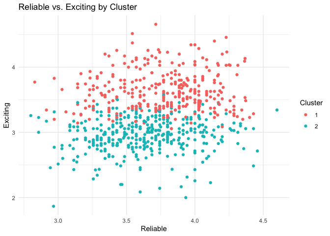

```r
ggplot(brands, aes(x = reliable, y = exciting, color = factor(cluster))) +
  geom_point() +
  labs(title = "Reliable vs. Exciting by Cluster", x = "Reliable", y = "Exciting", color = "Cluster") + theme_minimal()
```

*Thank you for your time :)*